# Data Management avec R

Philéas Condemine

04 juin 2018

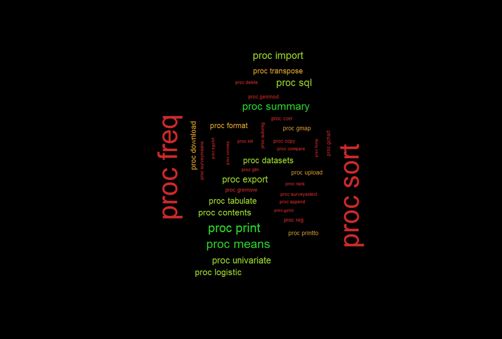

# Introduction

Ce notebook propose une introduction au data management avec le langage `R` et s’appuyant principalement sur le package `dplyr`.  
Nous terminons ce notebook par un exemple d’appel de script `R` dans `SAS` et la réalisation d’un modèle de régression logistique.

# Chargement de packages/librairies dans R

Pour le data management on va principalement s’appuyer sur la librairie `dplyr`, on pourrait aussi utiliser `data.table`. Pour le chargement de tables SAS on utilise la librarie `haven`. Pour réaliser des graphiques on utilise `ggplot2`.

```r
library(dplyr)
library(data.table)
library(haven)
library(ggplot2)
```

# Lecture/chargement de données

Pour charger une table SAS en mémoire dans un data.frame on utilise la fonction `read_sas`.  
Pour charger un fichier CSV dans un data.frame on peut utiliser les fonctions `read.csv` ou `read.csv2`.  
Le format SAS est bien plus lourd à lire que le format csv, pour gagner du temps de lecture on préférera les exports en CSV.  
[Facultatif] Pour des questions de simplicité et de performance on préférera souvent la fonction `fread` (fast read) qui demande moins de paramétrage et est souvent bien plus rapide. Cette fonction provient du package `data.table` et charge les tables dans un format dérivé des `data.frame` qui s’appelle les `data.table`. La syntaxe est différente mais on peut facilement passer de data.frame à data.table et réciproquement pour jongler entre les différentes syntaxes.  
Tout comme SAS génère des tables SAS, R peut générer des exports dans un format optimisé pour R, ce format est RData, on sauvegarde/charge ce format avec les fonctions `save`/`load`.

```r
data_sas <- haven::read_sas("data/barometre2016_fin.sas7bdat")
data_csv <- data.table::fread("data/barometre2016_fin.csv")
load("data/barometre2016_fin.RData")
```

# Ecriture de données

On peut écrire des fichiers SAS avec la fonction `write_sas()` pour conserver les formats, mais pour aller au plus vite et au plus standard on préférera écrire des CSV

```r
haven::write_sas(data = data_sas,path = "data/barometre2016_fin_fromR.sas7bdat")
save(list=c("data_sas"),file="data/barometre2016_fin.RData")
data.table::fwrite(x = data_sas,file = "data/barometre2016_fin.csv")
```

# Exploration d’un data.frame

## Noms des variables

On peut obtenir le vecteur des noms de chaque variable présente dans le data.frame avec la fonction `names`.

```r
names(data_sas)
```

```
##   [1] "mc26s1"                  "mc26s2"
##   [3] "mc26s3"                  "mc26s4"
##   [5] "mc26s5"                  "mc26s6"
##   [7] "mc27s1"                  "mc27s2"
##   [9] "mc27s3"                  "mc27s4"
##  [11] "mc27s5"                  "mc27s6"
##  [13] "mc27s7"                  "mc27s8"
##  [15] "mc27s9"                  "age"
##  [17] "pcs7"                    "sexe"
##  [19] "sit16"                   "sd_sitprof_6"
##  [21] "mh5_score"               "DEP"
##  [23] "annee"                   "poids_ind"
##  [25] "poids_ind_metro"         "sit_financiere_percue"
##  [27] "sit_financiere_percue_3" "sd_diplome3"
##  [29] "sd_revenus_3K"           "sd_vitseul"
```

[output cut: 109 more lines]

On peut décider de renommer une variable avec la fonction `rename`. Par exemple on veut renommer les variables DEP et sexe en zone et genre

```r
data_sas%>%rename(zone=DEP,genre=sexe)%>%
  select(zone,genre)
```

| zone | genre |
| --- | --- |
| Métropole | Femmes |
| Métropole | Femmes |
| Métropole | Hommes |
| Métropole | Femmes |
| Métropole | Hommes |
| Métropole | Hommes |
| Métropole | Femmes |
| Métropole | Femmes |
| Métropole | Hommes |
| Métropole | Femmes |

[output cut: 9990 more lines]

## Dimensions du data.frame

On peut connaître les dimensions de la table avec les fonctions `dim` `nrow` `ncol`

```r
dim(data_sas)
```

```
## [1] 32371   247
```

```r
ncol(data_sas)
```

```
## [1] 247
```

```r
nrow(data_sas)
```

```
## [1] 32371
```

# Inspection rapide des variables

## structure str

On peut utiliser la fonction `str` comme structure pour connaître la structure de chaque variable : type et première observations.

```r
str(data_sas)
```

```
## Classes 'tbl_df', 'tbl' and 'data.frame':    32371 obs. of  247 variables:
##  $ mc26s1                 : atomic  5 NA NA NA NA NA NA 5 NA NA ...
##   ..- attr(*, "format.sas")= chr "BEST"
##  $ mc26s2                 : atomic  NA NA NA NA NA NA NA 0 NA NA ...
##   ..- attr(*, "format.sas")= chr "BEST"
##  $ mc26s3                 : atomic  1 NA NA NA NA NA NA 3 NA NA ...
##   ..- attr(*, "format.sas")= chr "BEST"
##  $ mc26s4                 : atomic  0 NA NA NA NA NA NA 0 NA NA ...
##   ..- attr(*, "format.sas")= chr "BEST"
##  $ mc26s5                 : atomic  0 NA NA NA NA NA NA 0 NA NA ...
##   ..- attr(*, "format.sas")= chr "BEST"
##  $ mc26s6                 : atomic  0 NA NA NA NA NA NA 0 NA NA ...
##   ..- attr(*, "format.sas")= chr "BEST"
##  $ mc27s1                 : Factor w/ 3 levels "","non","oui": 1 1 1 1 1 1 1 3 1 1 ...
##  $ mc27s2                 : Factor w/ 4 levels "","[nsp]","non",..: 1 4 4 4 4 4 4 1 4 4 ...
```

[output cut: 100 more lines]

On peut utiliser la fonction `summary` pour connaître quelques statistiques descriptives sur chaque variable :

## sommaire summary

### sur le data.frame entier

```r
summary(data_sas)
```

```
##      mc26s1           mc26s2          mc26s3           mc26s4
##  Min.   : 0.000   Min.   :0.0     Min.   : 0.000   Min.   :  0.000
##  1st Qu.: 3.000   1st Qu.:0.0     1st Qu.: 1.000   1st Qu.:  0.000
##  Median : 4.000   Median :0.0     Median : 2.000   Median :  0.000
##  Mean   : 5.588   Mean   :0.2     Mean   : 3.001   Mean   :  4.832
##  3rd Qu.: 6.000   3rd Qu.:0.0     3rd Qu.: 3.000   3rd Qu.:  1.000
##  Max.   :72.000   Max.   :3.0     Max.   :70.000   Max.   :365.000
##  NA's   :30351    NA's   :32331   NA's   :30347    NA's   :30348
##      mc26s5            mc26s6      mc27s1        mc27s2      mc27s3
##  Min.   :  0.000   Min.   : 0.00      :31658        :25837    :31865
##  1st Qu.:  0.000   1st Qu.: 0.00   non:  437   [nsp]:    3   n:  491
##  Median :  0.000   Median : 0.00   oui:  276   non  : 1093   o:   15
##  Mean   :  5.641   Mean   : 0.21               oui  : 5438
##  3rd Qu.:  1.000   3rd Qu.: 0.00
##  Max.   :365.000   Max.   :45.00
##  NA's   :30346     NA's   :30333
##    mc27s4        mc27s5        mc27s6        mc27s7        mc27s8
##       :27628        :23798        :23798        :23798        :23798
##  [nsp]:    1   [nsp]:    1   [nsp]:    2   [nsp]:   20   [nsp]:    5
##  non  : 1973   non  : 7882   non  : 3565   non  : 7867   non  : 8208
##  oui  : 2769   oui  :  690   oui  : 5006   oui  :  686   oui  :  360
##
##
##
##    mc27s9           age
##       :25837   Min.   :15.00
##  [nsp]:    3   1st Qu.:31.00
##  non  : 4327   Median :44.00
##  oui  : 2204   Mean   :44.25
##                3rd Qu.:57.00
##                Max.   :75.00
##
##                                      pcs7          sexe       sit16
##  Employés                              :9545   Femmes:17944      :24067
##  Professions intermédiaires...         :8381   Hommes:14427   [ns:   85
##  Ouvriers                              :6178                  [ou:   26
##  Cadres, professions intellectuelles...:5200                  non:  657
##  Artisans, commerçants,...             :1915                  oui: 7536
##  Agriculteurs exploitants              : 537
##  (Other)                               : 615
```

[output cut: 593 more lines]

```
##  Min.   :0.000    :24208     :24208    Min.   :0.000   Min.   :0.000
##  1st Qu.:0.000   0: 7372    0: 6513    1st Qu.:0.000   1st Qu.:0.000
##  Median :1.000   1:  791    1: 1650    Median :0.000   Median :0.000
##  Mean   :0.577                         Mean   :0.359   Mean   :0.397
##  3rd Qu.:1.000                         3rd Qu.:1.000   3rd Qu.:1.000
##  Max.   :1.000                         Max.   :1.000   Max.   :1.000
##  NA's   :24212                         NA's   :15661   NA's   :24228
##  renoncement_soin_fin renoncement_soin_nonfin renoncement_soin
##  Min.   :0.000        Min.   :0.000           Min.   :0.0
##  1st Qu.:0.000        1st Qu.:0.000           1st Qu.:0.0
##  Median :0.000        Median :0.000           Median :0.0
##  Mean   :0.255        Mean   :0.256           Mean   :0.4
##  3rd Qu.:1.000        3rd Qu.:1.000           3rd Qu.:1.0
##  Max.   :1.000        Max.   :1.000           Max.   :1.0
##  NA's   :8573         NA's   :8573            NA's   :8573
```

### variable par variable, en sélectionnant sur les variables numériques

```r
lapply(data_sas%>%select_if(is.numeric),summary)
```

```
## $mc26s1
##    Min. 1st Qu.  Median    Mean 3rd Qu.    Max.    NA's
##   0.000   3.000   4.000   5.588   6.000  72.000   30351
##
## $mc26s2
##    Min. 1st Qu.  Median    Mean 3rd Qu.    Max.    NA's
##     0.0     0.0     0.0     0.2     0.0     3.0   32331
##
## $mc26s3
##    Min. 1st Qu.  Median    Mean 3rd Qu.    Max.    NA's
##   0.000   1.000   2.000   3.001   3.000  70.000   30347
##
## $mc26s4
##    Min. 1st Qu.  Median    Mean 3rd Qu.    Max.    NA's
##   0.000   0.000   0.000   4.832   1.000 365.000   30348
##
## $mc26s5
##    Min. 1st Qu.  Median    Mean 3rd Qu.    Max.    NA's
##   0.000   0.000   0.000   5.641   1.000 365.000   30346
##
## $mc26s6
##    Min. 1st Qu.  Median    Mean 3rd Qu.    Max.    NA's
##    0.00    0.00    0.00    0.21    0.00   45.00   30333
##
## $age
##    Min. 1st Qu.  Median    Mean 3rd Qu.    Max.
##   15.00   31.00   44.00   44.25   57.00   75.00
##
## $mh5_score
##    Min. 1st Qu.  Median    Mean 3rd Qu.    Max.    NA's
##    0.00   60.00   75.00   70.71   85.00  100.00       5
##
## $annee
##    Min. 1st Qu.  Median    Mean 3rd Qu.    Max.
##    2010    2010    2014    2013    2014    2014
##
## $poids_ind
##     Min.  1st Qu.   Median     Mean  3rd Qu.     Max.
##  0.05322  0.55661  0.84126  0.99637  1.18021 13.00816
##
```

[output cut: 116 more lines]

```
## $consult_opht
##    Min. 1st Qu.  Median    Mean 3rd Qu.    Max.    NA's
##   0.000   0.000   0.000   0.397   1.000   1.000   24228
##
## $renoncement_soin_fin
##    Min. 1st Qu.  Median    Mean 3rd Qu.    Max.    NA's
##   0.000   0.000   0.000   0.255   1.000   1.000    8573
##
## $renoncement_soin_nonfin
##    Min. 1st Qu.  Median    Mean 3rd Qu.    Max.    NA's
##   0.000   0.000   0.000   0.256   1.000   1.000    8573
##
## $renoncement_soin
##    Min. 1st Qu.  Median    Mean 3rd Qu.    Max.    NA's
##     0.0     0.0     0.0     0.4     1.0     1.0    8573
```

## freq/tabulate table

Pour connaître la distribution d’une variable catégorielle, on peut utiliser la fonction `table` qui est assez proche de la PROC FREQ. Pour ajouter les marges ont utilise la fonction `addmargins`.

```r
decompte_sexe=table(data_sas$sexe)
decompte_sexe
```

```
##
## Femmes Hommes
##  17944  14427
```

```r
addmargins(decompte_sexe)
```

```
##
## Femmes Hommes    Sum
##  17944  14427  32371
```

Si on s’intéresse à la proportion et non au décompte, on peut rapporter le décompte au nombre d’observations non manquantes, ou bien s’intéresse à des fonctions telles que `prop.table`.

```r
table(data_sas$sexe)/sum(!is.na(data_sas$sexe))
```

```
##
##    Femmes    Hommes
## 0.5543233 0.4456767
```

```r
prop.table(decompte_sexe)
```

```
##
##    Femmes    Hommes
## 0.5543233 0.4456767
```

Bien sûr on peut réaliser des tableaux croisés sur plusieurs variables.  
Vous trouverez des explications supplémentaires en français sur [ce site](http://olivier.godechot.free.fr/hoparticle.php?id_art=465).

```r
decompte_sexe_age=table(data_sas$sexe,data_sas$age)
addmargins(decompte_sexe_age)
```

```
##
##             15    16    17    18    19    20    21    22    23    24    25
##   Femmes   190   152   216   257   229   261   259   241   254   257   294
##   Hommes   162   183   223   218   219   231   197   240   201   258   252
##   Sum      352   335   439   475   448   492   456   481   455   515   546
##
##             26    27    28    29    30    31    32    33    34    35    36
##   Femmes   242   245   285   262   343   269   358   306   311   393   293
##   Hommes   206   234   266   245   278   228   248   280   254   308   287
##   Sum      448   479   551   507   621   497   606   586   565   701   580
##
##             37    38    39    40    41    42    43    44    45    46    47
##   Femmes   331   323   317   499   291   374   348   358   380   338   377
##   Hommes   272   294   303   338   278   336   306   282   296   278   292
##   Sum      603   617   620   837   569   710   654   640   676   616   669
##
##             48    49    50    51    52    53    54    55    56    57    58
##   Femmes   317   320   475   286   388   295   332   308   344   348   345
##   Hommes   265   252   355   236   275   263   225   260   237   259   255
##   Sum      582   572   830   522   663   558   557   568   581   607   600
##
##             59    60    61    62    63    64    65    66    67    68    69
##   Femmes   346   414   310   341   271   293   315   249   249   235   212
##   Hommes   280   270   203   254   248   220   235   164   186   165   155
##   Sum      626   684   513   595   519   513   550   413   435   400   367
##
##             70    71    72    73    74    75   Sum
##   Femmes   262   147   194   154   171   170 17944
##   Hommes   170   100   123   107    85    87 14427
##   Sum      432   247   317   261   256   257 32371
```

```r
decompte_sexe_age%>%prop.table(2)%>%addmargins
```

```
##
##                  15         16         17         18         19         20
##   Femmes  0.5397727  0.4537313  0.4920273  0.5410526  0.5111607  0.5304878
##   Hommes  0.4602273  0.5462687  0.5079727  0.4589474  0.4888393  0.4695122
##   Sum     1.0000000  1.0000000  1.0000000  1.0000000  1.0000000  1.0000000
##
##                  21         22         23         24         25         26
##   Femmes  0.5679825  0.5010395  0.5582418  0.4990291  0.5384615  0.5401786
##   Hommes  0.4320175  0.4989605  0.4417582  0.5009709  0.4615385  0.4598214
##   Sum     1.0000000  1.0000000  1.0000000  1.0000000  1.0000000  1.0000000
##
##                  27         28         29         30         31         32
##   Femmes  0.5114823  0.5172414  0.5167653  0.5523349  0.5412475  0.5907591
##   Hommes  0.4885177  0.4827586  0.4832347  0.4476651  0.4587525  0.4092409
##   Sum     1.0000000  1.0000000  1.0000000  1.0000000  1.0000000  1.0000000
##
##                  33         34         35         36         37         38
##   Femmes  0.5221843  0.5504425  0.5606277  0.5051724  0.5489221  0.5235008
##   Hommes  0.4778157  0.4495575  0.4393723  0.4948276  0.4510779  0.4764992
##   Sum     1.0000000  1.0000000  1.0000000  1.0000000  1.0000000  1.0000000
##
##                  39         40         41         42         43         44
##   Femmes  0.5112903  0.5961768  0.5114236  0.5267606  0.5321101  0.5593750
##   Hommes  0.4887097  0.4038232  0.4885764  0.4732394  0.4678899  0.4406250
##   Sum     1.0000000  1.0000000  1.0000000  1.0000000  1.0000000  1.0000000
##
##                  45         46         47         48         49         50
##   Femmes  0.5621302  0.5487013  0.5635277  0.5446735  0.5594406  0.5722892
##   Hommes  0.4378698  0.4512987  0.4364723  0.4553265  0.4405594  0.4277108
##   Sum     1.0000000  1.0000000  1.0000000  1.0000000  1.0000000  1.0000000
##
##                  51         52         53         54         55         56
##   Femmes  0.5478927  0.5852187  0.5286738  0.5960503  0.5422535  0.5920826
##   Hommes  0.4521073  0.4147813  0.4713262  0.4039497  0.4577465  0.4079174
##   Sum     1.0000000  1.0000000  1.0000000  1.0000000  1.0000000  1.0000000
##
##                  57         58         59         60         61         62
##   Femmes  0.5733114  0.5750000  0.5527157  0.6052632  0.6042885  0.5731092
##   Hommes  0.4266886  0.4250000  0.4472843  0.3947368  0.3957115  0.4268908
##   Sum     1.0000000  1.0000000  1.0000000  1.0000000  1.0000000  1.0000000
##
##                  63         64         65         66         67         68
##   Femmes  0.5221580  0.5711501  0.5727273  0.6029056  0.5724138  0.5875000
##   Hommes  0.4778420  0.4288499  0.4272727  0.3970944  0.4275862  0.4125000
##   Sum     1.0000000  1.0000000  1.0000000  1.0000000  1.0000000  1.0000000
##
##                  69         70         71         72         73         74
##   Femmes  0.5776567  0.6064815  0.5951417  0.6119874  0.5900383  0.6679688
##   Hommes  0.4223433  0.3935185  0.4048583  0.3880126  0.4099617  0.3320312
##   Sum     1.0000000  1.0000000  1.0000000  1.0000000  1.0000000  1.0000000
##
##                  75        Sum
##   Femmes  0.6614786 33.9172116
##   Hommes  0.3385214 27.0827884
##   Sum     1.0000000 61.0000000
```

On peut aussi trouver de l’inspiration avec les packages reshape2, dplyr, data.table et pander.  
[Ici](https://www.developpez.net/forums/d1578300/autres-langages/autres-langages/r/tableaux-croises-dynamiques-r/) une discussion sur le sujet en français.

# Manipulation de données

## Modification/création de variables

On peut créer/modifier une/plusieur variables avec les fonctions `mutate`, `mutate_if`, `mutate_at`, `mutate_all`.  
Ici on réalise un traitement standard dans R qui consiste à transformer les variables de type chaînes de caractères `character` en variable catégorielle/factorielle `factor`.

```r
data_sas=data_sas%>%mutate_if(is.character,factor)
```

## sélection sur variables (keep) ou observations (where ou delete)

### keep

Si on souhaite conserver seulement certaines variables, on peut utiliser la fonction `select` et lister les variables à garder.

```r
data_sas%>%select(annee,DEP,sexe,age,poids_ind,mh5_score)
```

| annee | DEP | sexe | age | poids_ind | mh5_score |
| --- | --- | --- | --- | --- | --- |
| 2010 | Métropole | Femmes | 50 | 1.2207430 | 50.00000 |
| 2010 | Métropole | Femmes | 52 | 1.8503320 | 75.00000 |
| 2010 | Métropole | Hommes | 34 | 1.5757030 | 85.00000 |
| 2010 | Métropole | Femmes | 69 | 0.8193527 | 85.00000 |
| 2010 | Métropole | Hommes | 52 | 1.4327500 | 60.00000 |
| 2010 | Métropole | Hommes | 53 | 1.1210190 | 85.00000 |
| 2010 | Métropole | Femmes | 52 | 2.2067260 | 80.00000 |
| 2010 | Métropole | Femmes | 18 | 1.0800310 | 40.00000 |
| 2010 | Métropole | Hommes | 52 | 0.9948424 | 75.00000 |
| 2010 | Métropole | Femmes | 47 | 1.0833420 | 60.00000 |

[output cut: 9990 more lines]

### remove/delete

Si à l’inverse on souhaite supprimer certaines variables, on peut utiliser la fonction `select` et faire précéder le nom des variables à supprimer d’un signe `-`.

```r
data_sas%>%ncol
```

```
## [1] 247
```

```r
data_sas%>%select(-mc26s1,-mc26s2)%>%ncol
```

```
## [1] 245
```

### filter

Si on souhaite ne conserver que les observations telles que la variable mh5_score est supérieure à 90.

```r
data_sas%>%nrow
```

```
## [1] 32371
```

```r
data_sas%>%filter(mh5_score>90)%>%nrow
```

```
## [1] 2646
```

## unique (distinct)

Si on souhaite supprimer les doublons, on peut utiliser la fonction `unique` ou la fonction `distinct` qui utilise la même syntaxe mais tourne beaucoup plus vite.

```r
system.time(data_sas%>%select(annee,DEP,sexe)%>%
  unique())
```

```
##    user  system elapsed
##    0.07    0.00    0.07
```

```r
system.time(data_sas%>%select(annee,DEP,sexe)%>%
  distinct())
```

```
##    user  system elapsed
##    0.01    0.00    0.01
```

## le tri

Afin de réaliser un tri sur une ou plusieurs variables, on peut utiliser la fonction `arrange`.

```r
data_sas%>%
  arrange(age)%>%
  select(annee,DEP,sexe,age,poids_ind,mh5_score)
```

| annee | DEP | sexe | age | poids_ind | mh5_score |
| --- | --- | --- | --- | --- | --- |
| 2010 | Métropole | Femmes | 15 | 1.0800310 | 70.00000 |
| 2010 | Métropole | Hommes | 15 | 2.0333400 | 70.00000 |
| 2010 | Métropole | Hommes | 15 | 5.5134720 | 60.00000 |
| 2010 | Métropole | Hommes | 15 | 1.0166700 | 80.00000 |
| 2010 | Métropole | Hommes | 15 | 1.0166700 | 75.00000 |
| 2010 | Métropole | Hommes | 15 | 4.5945600 | 90.00000 |
| 2010 | Métropole | Hommes | 15 | 2.0333400 | 85.00000 |
| 2010 | Métropole | Hommes | 15 | 1.5250050 | 65.00000 |
| 2010 | Métropole | Femmes | 15 | 1.0800310 | 75.00000 |
| 2010 | Métropole | Femmes | 15 | 1.7487730 | 90.00000 |

[output cut: 9990 more lines]

## création de nouvelles variables

On est souvent amené à créer de nouvelles variables, traitons quelques exemples classiques. On fera le plus souvent appel à la fonction `mutate`

### tranches

Disons qu’on souhaite découper la variable âge en tranches de 10 ans.

```
if       age < 10 then tage = "1";
if 10 <= age < 20 then tage = "2";
if 20 <= age < 30 then tage = "3";
if 30 <= age < 40 then tage = "4";
if 40 <= age < 50 then tage = "5";
if 50 <= age < 60 then tage = "6";
if 60 <= age < 70 then tage = "7";
if 70 <= age < 80 then tage = "8";
if 80 <= age      then tage = "9";
```

Le découpage de la variable peut être effectué avec les fonctions `cut` ou `Hmisc::cut2`

```r
data_sas%>%mutate(tage=cut(age,breaks = c(min(age),1:7*10,max(age)))) -> data_sas
table(data_sas$tage)
```

```
##
## (10,15] (15,20] (20,30] (30,40] (40,50] (50,60] (60,70] (70,75]
##     352    2189    5059    6212    6518    5966    4737    1338
```

### Création de variables par somme ou collage

Disons qu’on veut créer une variable de catégorie age x genre, pour cela on va utiliser `paste`.  
On souhaite également compter le nombre de spécialités consultées, on va donc appeler `sum` sur les lignes en précisant `rowwise`. On pourrait tout simplement utiliser l’opérateur `+`.

```r
data_sas%>%
  mutate(age_sexe=paste(sexe,age,sep="_"))%>%
  rowwise() %>%
  mutate(consult = sum(consult_mg,
                       consult_dentiste,
                       consult_gyneco,
                       consult_opht,
                       na.rm=TRUE)) -> data_sas
data_sas$age_sexe%>%table%>%sort(decreasing = T)%>%head(10)
```

```
## .
## Femmes_40 Femmes_50 Femmes_60 Femmes_35 Femmes_52 Femmes_45 Femmes_47
##       499       475       414       393       388       380       377
## Femmes_42 Femmes_32 Femmes_44
##       374       358       358
```

```r
data_sas$consult%>%table
```

```
## .
##     0     1     2     3
## 16823  4943  6757  3848
```

### [Niveau avancé] lag (décalage)

Cet exemple et très complet et fait appel aux fonctions `filter`, `group_by`, `summarise`, `arrange`, `mutate`, `ggplot`, pour gagner quelques lignes de code on fait même appel à la fonction `set` (`:=`) de `data.table` pour faire un group_by “sur place”.  
On étudie parfois des séries temporelles ou données de panel et on a besoin de comparer $X_t$ avec $X_{t-1}$, pour cela on doit créer une variable de retard/lag, par groupe.  
Par exemple, disons qu’on veut comparer, à genre et zone donnés, le niveau d’isolement à l’âge A et à l’âge A+1.

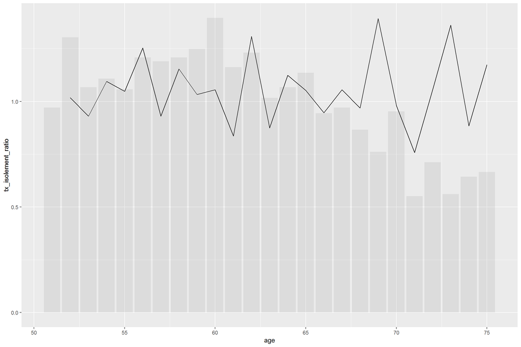

```r
# niveau d'isolement par âge, genre, zone
data_sas%>%
  filter(age>50)%>%
  group_by(DEP,age,sexe)%>%
  summarise(volume=n(),
            # volume_noNA=sum(!is.na(sd_vitseul)),
            isolement=sum(sd_vitseul=="Oui"),
            tx_isolement=isolement/volume)%>%
  arrange(DEP,sexe,age)%>%
  data.table-> data_sas_dt
#lag par genre et zone
data_sas_dt[,c("tx_isolement_lag"):=list(lag(tx_isolement)),by=c("DEP","sexe")]

#ratio et visualisation pour une zone et un genre donnés
data_sas_dt%>%
  mutate(tx_isolement_ratio=tx_isolement/tx_isolement_lag)%>%
  filter(DEP=="Métropole"&sexe=="Femmes")%>%
  mutate(volume=volume/mean(volume))%>%
  ggplot() -> g

g+geom_line(aes(x=age,y=tx_isolement_ratio))+geom_col(aes(x=age,y=volume),alpha=.1)
```

## group by

```r
nb_Q23=data_sas%>%
  group_by(Q23)%>%
  summarise(mh5_filled_in_Q23=sum(!is.na(mh5_score)))%>%
  filter(mh5_filled_in_Q23>10)
```

## jointure (merge)

```r
data_sas_sub=merge(data_sas,nb_Q23,by="Q23", all.x=F,all.y=F)
```

Pour réaliser la même opération on aurait pû utiliser une syntaxe data.table :

```r
data_sas=data.table(data_sas)
data_sas[,"mh5_filled_in_Q23":=sum(!is.na(mh5_score)),by="Q23"]
data_sas_sub=data_sas[mh5_filled_in_Q23>10]
```

# proc compare

## Exemple simple

### Code SAS

```
DATA version1;
   INPUT id $ age sexe;
   DATALINES;
1 20 1
2 30 2
3 40 2
4 50 1
5 60 2
    ;
RUN;

DATA version2;
   INPUT id $ age;
   DATALINES;
1 20
2 30
3 30
5 70
    ;
RUN;

PROC COMPARE DATA = version1
            COMPARE = version2;
    ID id;
RUN;
```

### package arsenal

```r
library(arsenal)
version1=data.frame(id=1:5,age=c(2:6*10),sexe=sample(1:2,replace = T,size = 5))
version2=data.frame(id=c(1,2,3,5),age=c(20,30,30,70))
exemple1=compare(version1, version2,by="id")
exemple1$vars.summary$values[[2]]
```

|  | id | values.x | values.y | row.x | row.y |
| --- | --- | --- | --- | --- | --- |
| 3 | 3 | 40 | 30 | 3 | 3 |
| 5 | 5 | 60 | 70 | 5 | 4 |

```r
# summary(exemple1)
# diffs(exemple1)
```

## Autre exemple

### data

```r
d1
```

| Last_Name | First_Name | Street_Address | ZIP | VisitCount |
| --- | --- | --- | --- | --- |
| Doe | John | 1234 Main St | 12345 | 20 |
| Doe | Jane | 4321 Tower St | 54321 | 10 |
| Don | Bob | 771 North Ave | 23232 | 5 |
| Smith | Mike | 732 South Blvd. | 77777 | 3 |

```r
d2
```

| Last_Name | First_Name | Street_Address | ZIP | VisitCount |
| --- | --- | --- | --- | --- |
| Doe | John | 1234 Main St | 12345 | 20 |
| Doe | Jane | 4111 Tower St | 32132 | 17 |
| Donn | Bob | 771 North Ave | 11111 | 5 |

### Package arsenal

https://cran.r-project.org/web/packages/arsenal/vignettes/compare.html

```r
library(arsenal)
comparison=compare(d1,d2)
comparison
```

[output not shown]

```r
summary(comparison)
```

```
##
##
## Table: Variables not shared
##
## |                        |
## |:-----------------------|
## |No variables not shared |
##
##
##
## Table: Other variables not compared
##
## |                                |
## |:-------------------------------|
## |No other variables not compared |
##
##
##
## Table: Observations not shared
##
## version    ..row.names..   observation
## --------  --------------  ------------
## x                      4             4
##
##
##
## Table: Differences detected by variable
##
## var.x            var.y              n   NAs
## ---------------  ---------------  ---  ----
## Last_Name        Last_Name          1     0
## First_Name       First_Name         0     0
## Street_Address   Street_Address     1     0
## ZIP              ZIP                2     0
## VisitCount       VisitCount         1     0
##
##
##
## Table: First 10 differences detected per variable
##
## var.x            var.y             ..row.names..  values.x        values.y         row.x   row.y
## ---------------  ---------------  --------------  --------------  --------------  ------  ------
## Last_Name        Last_Name                     3  Don             Donn                 3       3
## Street_Address   Street_Address                2  4321 Tower St   4111 Tower St        2       2
## ZIP              ZIP                           2  54321           32132                2       2
## ZIP              ZIP                           3  23232           11111                3       3
## VisitCount       VisitCount                    2  10              17                   2       2
##
##
##
## Table: Non-identical attributes
##
## |                            |
## |:---------------------------|
## |No non-identical attributes |
```

```r
summary(compare(d1,d2,by=c("Last_Name","First_Name")))
```

```
##
##
## Table: Variables not shared
##
## |                        |
## |:-----------------------|
## |No variables not shared |
##
##
##
## Table: Other variables not compared
##
## |                                |
## |:-------------------------------|
## |No other variables not compared |
##
##
##
## Table: Observations not shared
##
## version   Last_Name   First_Name    observation
## --------  ----------  -----------  ------------
## x         Don         Bob                     3
## x         Smith       Mike                    4
## y         Donn        Bob                     3
##
##
##
## Table: Differences detected by variable
##
## var.x            var.y              n   NAs
## ---------------  ---------------  ---  ----
## Street_Address   Street_Address     1     0
## ZIP              ZIP                1     0
## VisitCount       VisitCount         1     0
##
##
##
## Table: First 10 differences detected per variable
##
## var.x            var.y            Last_Name   First_Name   values.x        values.y         row.x   row.y
## ---------------  ---------------  ----------  -----------  --------------  --------------  ------  ------
## Street_Address   Street_Address   Doe         Jane         4321 Tower St   4111 Tower St        2       2
## ZIP              ZIP              Doe         Jane         54321           32132                2       2
## VisitCount       VisitCount       Doe         Jane         10              17                   2       2
##
##
##
## Table: Non-identical attributes
##
## |                            |
## |:---------------------------|
## |No non-identical attributes |
```

```r
diffs(comparison)
```

|  | var.x | var.y | ..row.names.. | values.x | values.y | row.x | row.y |
| --- | --- | --- | --- | --- | --- | --- | --- |
| 1 | Last_Name | Last_Name | 3 |  |  | 3 | 3 |
| 2 | Street_Address | Street_Address | 2 |  |  | 2 | 2 |
| 3 | ZIP | ZIP | 2 |  |  | 2 | 2 |
| 4 | ZIP | ZIP | 3 |  |  | 3 | 3 |
| 5 | VisitCount | VisitCount | 2 |  |  | 2 | 2 |

```r
diffs(comparison,by.var=T)
```

|  | var.x | var.y | n | NAs |
| --- | --- | --- | --- | --- |
| 1 | Last_Name | Last_Name | 1 | 0 |
| 2 | First_Name | First_Name | 0 | 0 |
| 3 | Street_Address | Street_Address | 1 | 0 |
| 4 | ZIP | ZIP | 2 | 0 |
| 5 | VisitCount | VisitCount | 1 | 0 |

### Une piste intéressante avec data.table

https://stackoverflow.com/questions/28056805/find-discrepancies-between-two-tables

```r
setDT(d1)
d1 <- d1[, list(VarName = names(.SD), TableOne = unlist(.SD, use.names = F)),by=c('Last_Name','First_Name')]

setDT(d2)
d2 <- d2[, list(VarName = names(.SD), TableTwo = unlist(.SD, use.names = F)),by=c('Last_Name','First_Name')]

# Set keys for merging
setkey(d1,Last_Name,First_Name,VarName)

# Merge, remove duplicates
d1[d2,nomatch=0][TableOne!=TableTwo]
```

| Last_Name | First_Name | VarName | TableOne | TableTwo |
| --- | --- | --- | --- | --- |
| Doe | Jane | Street_Address | 4321 Tower St | 4111 Tower St |
| Doe | Jane | ZIP | 54321 | 32132 |
| Doe | Jane | VisitCount | 10 | 17 |

# fonctions pour les chaînes de caractère

## find, count dans SAS

Où est la première occurrence de “consult” ? `match = find(nm, "consult");`

Combien d’occurrence de l’expression “consult” ? `howmany = count(nm, "consult");`

## grep

Concept plus riche avec [grep](https://fr.wikipedia.org/wiki/Grep)

```r
nm=names(data_sas)
nm[grep(pattern = "consult",x = nm)]
```

```
## [1] "consult_mg"       "consult_dentiste" "consult_gyneco"
## [4] "consult_spe"      "consult_opht"     "consult"
```

## substr

```r
data_sas%>%
  select(Q32_spec_1)%>%
  mutate(Q32_spec_char=as.character(Q32_spec_1),
         Q32_spec_len=nchar(Q32_spec_char))%>%
  filter(Q32_spec_len>1)%>%
  mutate(Q32_spec_1a3=substr(Q32_spec_char,start = 1,stop = 3))%>%
  select(Q32_spec_char,Q32_spec_1a3)
```

| Q32_spec_char | Q32_spec_1a3 |
| --- | --- |
| Médecin du sport/du travail | Méd |
| Cardiologue | Car |
| Dermatologue | Der |
| NSP | NSP |
| Rhumatologue (médecin pour hernie, artht | Rhu |
| Ostéopathe | Ost |
| Diététicien/nutritionniste | Dié |
| NSP | NSP |
| ORL | ORL |
| NSP | NSP |

[output cut: 2228 more lines]

# Fonctions de simulation/échantillonnage

## Tirage aléatoire

On s’intéresse à la variable`Q32_spec_1` relative aux spécialités médicales. On veut simuler un vecteur de 1000 spécialistes. On commence par calculer la distribution des modalités avec un équivalent proc freq : `table` puis on réalise le tirage aléatoire pondéré avec la fonction `sample`

```r
freq_Q33=data_sas%>%filter(!Q32_spec_1=="")%>%
                              mutate(Q32_spec_1=as.character(Q32_spec_1))%>%
                              select(Q32_spec_1)%>%table
freq_Q33
```

```
## .
##                              Acupuncteur
##                                        5
##                             Allergologue
##                                       62
##                               Angiologue
##                                       23
##                  Autres non spécialistes
##                                       21
##                      Autres spécialistes
##                                       43
##                 Cancerologue / oncologue
##                                       56
##                              Cardiologue
##                                      393
##                  Chiropracteur/Etiopathe
##                                        7
##                  Chirurgien/anesthésiste
##                                      102
##                             Dermatologue
##                                      185
##            Diabétologue / endocrinologue
##                                      111
##               Diététicien/nutritionniste
##                                       20
##                            Drepanocytose
##                                        2
##                         Estomac/intestin
##                                        3
##           Gastro-entérologue/hépatologue
##                                      114
##                 Gynécologue/obstétricien
##                                        3
##                              Hématologue
##                                        6
##                               Homéopathe
##                                        6
##              Médecin du sport/du travail
##                                       18
##                              Nephrologue
```

[output cut: 30 more lines]

```
##                                       27
##                              Psychologue
##                                       18
##                               Radiologue
##                                      101
## Rhumatologue (médecin pour hernie, artht
##                                      163
##               Spécialiste jambes, genous
##                                       15
##                             Stomatologue
##                                       10
##                            Traumatologue
##                                        5
##                                 Urologue
##                                       45
```

```r
sample(x = names(freq_Q33),size=1000,replace = T,prob = freq_Q33)
```

```
##    [1] "ORL"
##    [2] "Ostéopathe"
##    [3] "Gastro-entérologue/hépatologue"
##    [4] "Dermatologue"
##    [5] "Neurologue"
##    [6] "Gastro-entérologue/hépatologue"
##    [7] "ORL"
##    [8] "Cardiologue"
##    [9] "ORL"
##   [10] "Diabétologue / endocrinologue"
##   [11] "Dermatologue"
##   [12] "Cardiologue"
##   [13] "Angiologue"
##   [14] "Cardiologue"
##   [15] "Gastro-entérologue/hépatologue"
```

[output cut: 985 more lines]

# Retour aux PROC classiques

## Proc FREQ 100% paramétrable

Un équivalent proc freq avec des ajustements de mise en forme : pourcentage avec symbole % et arrondi à 2 décimales.

```r
lapply(data_sas%>%
         select_if(is.factor)%>%.[,1:10],
       function(x){
        x%>%
           tibble()%>%
           group_by_all()%>%
           summarise(volume=n(),
                     len=length(x),
                     freq_pct=round(100*volume/len,2),
                     freq_print=paste0(freq_pct,"%")
                     )%>%
           arrange(-freq_pct)%>%
           select(-volume,-len,-freq_pct)
})
```

```
## $mc27s1
## # A tibble: 3 x 2
##   .     freq_print
##   <fct> <chr>
## 1 ""    97.8%
## 2 non   1.35%
## 3 oui   0.85%
##
## $mc27s2
## # A tibble: 4 x 2
##   .     freq_print
##   <fct> <chr>
## 1 ""    79.82%
## 2 oui   16.8%
## 3 non   3.38%
## 4 [nsp] 0.01%
##
## $mc27s3
## # A tibble: 3 x 2
##   .     freq_print
##   <fct> <chr>
## 1 ""    98.44%
## 2 n     1.52%
## 3 o     0.05%
##
## $mc27s4
## # A tibble: 4 x 2
##   .     freq_print
##   <fct> <chr>
## 1 ""    85.35%
## 2 oui   8.55%
## 3 non   6.09%
## 4 [nsp] 0%
##
## $mc27s5
## # A tibble: 4 x 2
##   .     freq_print
##   <fct> <chr>
## 1 ""    73.52%
## 2 non   24.35%
```

[output cut: 36 more lines]

```
## 3 oui   6.81%
## 4 [nsp] 0.01%
##
## $pcs7
## # A tibble: 8 x 2
##   .                                      freq_print
##   <fct>                                  <chr>
## 1 Employés                               29.49%
## 2 Professions intermédiaires...          25.89%
## 3 Ouvriers                               19.08%
## 4 Cadres, professions intellectuelles... 16.06%
## 5 Artisans, commerçants,...              5.92%
## 6 Agriculteurs exploitants               1.66%
## 7 ""                                     0.95%
## 8 Sans activite (DOM seulement)          0.95%
```

## proc means, univariate, summary

```r
data_sas%>%
  filter(DEP%in%c("Métropole","Martinique"))%>%
  filter(!is.na(mh5_score))%>%
  group_by(age,sexe)%>%
  summarise(
    volume=n(),
    pond=sum(poids_ind),
    bonnesante_w=weighted.mean(bonnesante,w=poids_ind,na.rm=T),
    mh5_score_dec1=quantile(mh5_score,.1),
    mh5_score_dec9=quantile(mh5_score,.9),
    mh5_score_sd=sd(mh5_score),
    mh5_score_cl_inf=t.test(mh5_score)$conf.int[1],
    mh5_score_cl_sup=t.test(mh5_score)$conf.int[2],
    pbdent_w=weighted.mean(pbdent,w=poids_ind,na.rm=T))%>%
  arrange(age)
```

| age | sexe | volume | pond | bonnesante_w | mh5_score_dec1 | mh5_score_dec9 | mh5_score_sd | mh5_score_cl_inf | mh5_score_cl_sup | pbdent_w |
| --- | --- | --- | --- | --- | --- | --- | --- | --- | --- | --- |
| 15 | Femmes | 145 | 225.55271 | 0.7213730 | 47.0 | 90.00 | 16.30594 | 68.46138 | 73.81448 | 0.2400842 |
| 15 | Hommes | 133 | 237.63228 | 0.9540491 | 60.0 | 95.00 | 16.56431 | 74.33929 | 80.02161 | 0.2095618 |
| 16 | Femmes | 111 | 150.84925 | 0.7756652 | 40.0 | 85.00 | 17.61135 | 62.22783 | 68.85325 | 0.4441046 |
| 16 | Hommes | 139 | 199.17121 | 0.8433996 | 60.0 | 95.00 | 12.77048 | 75.66398 | 79.94753 | 0.1522109 |
| 17 | Femmes | 162 | 209.86081 | 0.7336265 | 50.0 | 85.00 | 16.43023 | 64.98162 | 70.08011 | 0.4756246 |
| 17 | Hommes | 165 | 221.43925 | 0.7686304 | 60.0 | 95.00 | 15.16264 | 75.85106 | 80.51258 | 0.3939993 |
| 18 | Femmes | 188 | 226.03011 | 0.6495573 | 40.0 | 85.00 | 17.91149 | 63.69956 | 68.85363 | 0.3027666 |
| 18 | Hommes | 157 | 194.23120 | 0.8103241 | 55.0 | 90.00 | 14.35639 | 74.16991 | 78.69634 | 0.1695888 |
| 19 | Femmes | 175 | 191.41769 | 0.7890910 | 40.0 | 85.00 | 17.45734 | 64.59542 | 69.80458 | 0.4151295 |
| 19 | Hommes | 163 | 194.16552 | 0.9146068 | 60.0 | 95.00 | 14.41919 | 74.79430 | 79.25478 | 0.2756857 |

[output cut: 112 more lines]

# Outils supplémentaires

## les boucles

cf formation

`do i = 1 %to 4`

```r
for (i in 1:4){
  print(i^2)
}
```

```
## [1] 1
## [1] 4
## [1] 9
## [1] 16
```

## les fonctions/macro

cf formation

# GLM

## GLM basique

GLM, choix des levels dans le GLM

https://stackoverflow.com/questions/23282048/logistic-regression-defining-reference-level-in-r

```r
data_sas%>%
  mutate(sexe = relevel(sexe, ref = "Femmes"),
         sd_diplome3 = relevel(sd_diplome3, ref = "< Bac"),
         sd_sitprof_6 = relevel(sd_sitprof_6, ref = "Chomage"),
         sit_financiere_percue = relevel(sit_financiere_percue, ref = "Ca va"),
         sd_revenus_3K = relevel(sd_revenus_3K, ref = "1er tercile (faible)")
  ) -> data_sas


logistic <- glm(bonnesante ~ age + sexe + sd_diplome3 + sd_sitprof_6 + sit_financiere_percue + sd_revenus_3K ,family=binomial(link=logit), data=data_sas%>%filter(DEP=="Métropole"), na.action = na.exclude)

summary(logistic)
```

```
##
## Call:
## glm(formula = bonnesante ~ age + sexe + sd_diplome3 + sd_sitprof_6 +
##     sit_financiere_percue + sd_revenus_3K, family = binomial(link = logit),
##     data = data_sas %>% filter(DEP == "Métropole"), na.action = na.exclude)
##
## Deviance Residuals:
##     Min       1Q   Median       3Q      Max
## -2.1462  -1.2005   0.6448   0.8555   1.5527
##
## Coefficients:
##                                          Estimate Std. Error z value
## (Intercept)                              2.119346   0.204001  10.389
## age                                     -0.027873   0.003421  -8.148
## sexeHommes                               0.128928   0.065129   1.980
## sd_diplome3                             12.641911 227.624984   0.056
## sd_diplome3> Bac                         0.368788   0.078637   4.690
## sd_diplome3Bac                           0.085883   0.087801   0.978
## sd_sitprof_6                             0.232424   1.177101   0.197
## sd_sitprof_6Autres ina                  -0.318371   0.179432  -1.774
## sd_sitprof_6Etudes                      -0.154651   0.189683  -0.815
## sd_sitprof_6Retraite                    -0.099666   0.162678  -0.613
## sd_sitprof_6Travail                     -0.060831   0.129616  -0.469
## sit_financiere_percue                    0.266234   0.583074   0.457
## sit_financiere_percueA l'aise            0.252130   0.101075   2.494
## sit_financiere_percueC'est difficile    -0.682505   0.109218  -6.249
## sit_financiere_percueC'est juste        -0.216673   0.080200  -2.702
## sit_financiere_percueN'y arrive pas sa  -1.062393   0.183790  -5.780
## sd_revenus_3K2nd tercile                 0.060777   0.089305   0.681
## sd_revenus_3K3ème tercile (élevé)        0.096390   0.100669   0.957
## sd_revenus_3KNSP/Refus                   0.218558   0.157462   1.388
##                                        Pr(>|z|)
## (Intercept)                             < 2e-16 ***
## age                                    3.69e-16 ***
## sexeHommes                               0.0478 *
## sd_diplome3                              0.9557
## sd_diplome3> Bac                       2.74e-06 ***
## sd_diplome3Bac                           0.3280
## sd_sitprof_6                             0.8435
## sd_sitprof_6Autres ina                   0.0760 .
## sd_sitprof_6Etudes                       0.4149
## sd_sitprof_6Retraite                     0.5401
## sd_sitprof_6Travail                      0.6388
## sit_financiere_percue                    0.6480
## sit_financiere_percueA l'aise            0.0126 *
## sit_financiere_percueC'est difficile   4.13e-10 ***
## sit_financiere_percueC'est juste         0.0069 **
## sit_financiere_percueN'y arrive pas sa 7.45e-09 ***
## sd_revenus_3K2nd tercile                 0.4962
## sd_revenus_3K3ème tercile (élevé)        0.3383
## sd_revenus_3KNSP/Refus                   0.1651
## ---
## Signif. codes:  0 '***' 0.001 '**' 0.01 '*' 0.05 '.' 0.1 ' ' 1
##
## (Dispersion parameter for binomial family taken to be 1)
##
##     Null deviance: 6221.0  on 5129  degrees of freedom
## Residual deviance: 5842.3  on 5111  degrees of freedom
##   (19078 observations deleted due to missingness)
## AIC: 5880.3
##
## Number of Fisher Scoring iterations: 12
```

## GLM interactions

```r
logistic <- glm(bonnesante ~ tage*sexe + sd_diplome3 + sd_sitprof_6 + sit_financiere_percue + sd_revenus_3K ,family=binomial(link=logit), data=data_sas%>%filter(DEP=="Métropole"), na.action = na.exclude)

summary(logistic)
```

```
##
## Call:
## glm(formula = bonnesante ~ tage * sexe + sd_diplome3 + sd_sitprof_6 +
##     sit_financiere_percue + sd_revenus_3K, family = binomial(link = logit),
##     data = data_sas %>% filter(DEP == "Métropole"), na.action = na.exclude)
##
## Deviance Residuals:
##     Min       1Q   Median       3Q      Max
## -2.4156  -1.1985   0.6457   0.8453   1.5514
##
## Coefficients:
##                                          Estimate Std. Error z value
## (Intercept)                              2.232618   0.777538   2.871
## tage(15,20]                             -1.196577   0.766194  -1.562
## tage(20,30]                             -0.756945   0.775132  -0.977
## tage(30,40]                             -1.010180   0.779019  -1.297
## tage(40,50]                             -1.329428   0.776598  -1.712
## tage(50,60]                             -1.708404   0.776273  -2.201
## tage(60,70]                             -1.941488   0.786580  -2.468
## tage(70,75]                             -2.368904   0.803072  -2.950
## sexeHommes                               0.237581   1.042046   0.228
## sd_diplome3                             12.736208 227.218117   0.056
## sd_diplome3> Bac                         0.349902   0.080998   4.320
## sd_diplome3Bac                           0.099249   0.088535   1.121
## sd_sitprof_6                             0.178972   1.187745   0.151
## sd_sitprof_6Autres ina                  -0.345126   0.179686  -1.921
## sd_sitprof_6Etudes                       0.125723   0.225268   0.558
## sd_sitprof_6Retraite                    -0.017245   0.189056  -0.091
## sd_sitprof_6Travail                     -0.098923   0.130210  -0.760
## sit_financiere_percue                    0.183084   0.583355   0.314
## sit_financiere_percueA l'aise            0.266062   0.101525   2.621
## sit_financiere_percueC'est difficile    -0.692915   0.109691  -6.317
## sit_financiere_percueC'est juste        -0.224301   0.080430  -2.789
## sit_financiere_percueN'y arrive pas sa  -1.072809   0.184371  -5.819
## sd_revenus_3K2nd tercile                 0.058783   0.089665   0.656
## sd_revenus_3K3ème tercile (élevé)        0.109055   0.101787   1.071
## sd_revenus_3KNSP/Refus                   0.234504   0.158095   1.483
## tage(15,20]:sexeHommes                   0.053656   1.082428   0.050
## tage(20,30]:sexeHommes                  -0.322285   1.058855  -0.304
## tage(30,40]:sexeHommes                  -0.156002   1.054517  -0.148
```

[output cut: 33 more lines]

```
## tage(40,50]:sexeHommes                  0.98280
## tage(50,60]:sexeHommes                  0.99646
## tage(60,70]:sexeHommes                  0.81197
## tage(70,75]:sexeHommes                  0.85061
## ---
## Signif. codes:  0 '***' 0.001 '**' 0.01 '*' 0.05 '.' 0.1 ' ' 1
##
## (Dispersion parameter for binomial family taken to be 1)
##
##     Null deviance: 6221.0  on 5129  degrees of freedom
## Residual deviance: 5826.2  on 5098  degrees of freedom
##   (19078 observations deleted due to missingness)
## AIC: 5890.2
##
## Number of Fisher Scoring iterations: 12
```

## Stepwise

Il est bien sûr possible de sélectionner des variables par méthode stepwise/forward/backward de manière “brutale” (brute-force), mais ce n’est pas recommandé pour de nombreuses raisons dont le risque d’overfitting et les temps de calcul trop longs.

- MASS::stepAIC
- stats::step

## régularisation/pénalisation (RIDGING)

Le package glmnet permet de faire des régressions L1 (LASSO), L2 (RIDGE) et Elastic-Net (mix L1-L2).  
Vous trouverez dans la [documentation](https://www.rdocumentation.org/packages/glmnet/versions/2.0-12/topics/glmnet) de très bons exemples en bas du document.

# Invocation de script R depuis SAS

Un exemple concret a été réalisé dans le contexte d’un projet de microsimulation des retraites. Une brique intermédiaire d’imputation a été codée en R et est maintenant invoquée depuis le “main.sas”.  
Pour cela il faut

- Installer R sur l’ordinateur
- Trouver le chemin vers le fichier Rscript.exe, dans mon cas `C:\Users\phileas.condemine\Documents\R\R-3.4.3\bin\Rscript.exe`
- Trouver le chemin vers le script R à éxécuter, dans mon cas `C:\Users\phileas.condemine\Documents\MicroSim\retraite\Programmes_R\Import_data_R.R`
- Un certain nombre de paramètres peuvent être renseignés dans la fonction, dans ce cas on a 5 paramètres : generation, working_directory, output_directory, path_to_excel_input, path_to_sas_input. Il faut renseigner les paramètres dans le bon ordre.
- L’appel de R par SAS s’appuie sur la fonction `pipe`.
- Voici le programme SAS qui invoque le script R.

```
options noxwait xsync;
filename proc_r pipe "C:\Users\phileas.condemine\Documents\R\R-3.4.3\bin\Rscript.exe --vanilla C:\Users\phileas.condemine\Documents\MicroSim\retraite\Programmes_R\Import_data_R.R 1976 C:/Users/phileas.condemine/Documents/MicroSim/retraite/ base_en_sortie/ Base_en_entree/ import_prepared_by_sas/";
data _null_;
infile proc_r;
run;
```

# Documentation

https://gitlab.com/DREES_code/OUTILS/Trucs_et_Astuces_en_R

Une documentation SAS->R à destination des statisticiens en laboratoires pharmaceutiques :  
https://www.lexjansen.com/phuse/2014/ad/AD04.pdf  
références aux PROC : IMPORT, CONTENTS, SQL, PRINT, MEANS, BOXPLOT, TTEST, SGPANEL, GLM, REG, ANOVA, MIXED, DOCUMENT